# Group comparisons - single gene and total DE

Arjan Boltjes

18/04/2019

## Introduction

To check whether the gene expression of OSMR and/or LIFR differ, we performed two types of logistic regression, and additionaly performed differential expression analysis for the entire gene set used, from which we can then filter OSMR/LIFR.

In order for the second part to work, make sure you ran the following two files, saved the df’s and loaded them here:  
First, run: RNAseq_analysis_part_1_import_and_tidy.Rmd  
Second, run: RNAseq_analysis_part_2_AE.Rmd

## Data import, tidying, and selection

```
## # A tibble: 51,768 x 378
##    ensembl_gene_id symbol chr    start    end strand ae1026 ae1029 ae1032
##    <chr>           <chr>  <chr>  <int>  <int> <chr>   <dbl>  <dbl>  <dbl>
##  1 ENSG00000184389 A3GAL… 01    3.38e7 3.38e7 -           0      0      0
##  2 ENSG00000188984 AADAC… 01    1.28e7 1.28e7 +           0      0      0
##  3 ENSG00000204518 AADAC… 01    1.27e7 1.27e7 +           0      0      0
##  4 ENSG00000198691 ABCA4  01    9.45e7 9.46e7 -           1      0      0
##  5 ENSG00000135776 ABCB10 01    2.30e8 2.30e8 -           0      0      0
##  6 ENSG00000117528 ABCD3  01    9.49e7 9.50e7 +           2      3      0
##  7 ENSG00000143322 ABL2   01    1.79e8 1.79e8 -          26     11      4
##  8 ENSG00000117054 ACADM  01    7.62e7 7.63e7 +           1      3      0
##  9 ENSG00000131584 ACAP3  01    1.23e6 1.24e6 -           1      2      0
## 10 ENSG00000182827 ACBD3  01    2.26e8 2.26e8 -          10      8      1
## # … with 51,758 more rows, and 369 more variables: ae1035 <dbl>,
## #   ae1054 <dbl>, ae1066 <dbl>, ae1074 <dbl>, ae1082 <dbl>, ae1100 <dbl>,
## #   ae112 <dbl>, ae113 <dbl>, ae114 <dbl>, ae1155 <dbl>, ae1157 <dbl>,
## #   ae116 <dbl>, ae1160 <dbl>, ae117 <dbl>, ae1173 <dbl>, ae1174 <dbl>,
## #   ae1178 <dbl>, ae1182 <dbl>, ae12 <dbl>, ae1203 <dbl>, ae121 <dbl>,
## #   ae1218 <dbl>, ae1229 <dbl>, ae1231 <dbl>, ae1248 <dbl>, ae1249 <dbl>,
## #   ae125 <dbl>, ae1258 <dbl>, ae1260 <dbl>, ae1286 <dbl>, ae1287 <dbl>,
## #   ae1296 <dbl>, ae1297 <dbl>, ae130 <dbl>, ae1303 <dbl>, ae1305 <dbl>,
## #   ae1306 <dbl>, ae1311 <dbl>, ae1324 <dbl>, ae1326 <dbl>, ae1334 <dbl>,
## #   ae1343 <dbl>, ae1346 <dbl>, ae1349 <dbl>, ae1351 <dbl>, ae1360 <dbl>,
## #   ae1367 <dbl>, ae137 <dbl>, ae1375 <dbl>, ae138 <dbl>, ae1389 <dbl>,
## #   ae1390 <dbl>, ae1402 <dbl>, ae1410 <dbl>, ae1411 <dbl>, ae1412 <dbl>,
## #   ae1420 <dbl>, ae1422 <dbl>, ae1425 <dbl>, ae1431 <dbl>, ae1446 <dbl>,
## #   ae1449 <dbl>, ae1461 <dbl>, ae147 <dbl>, ae1473 <dbl>, ae1481 <dbl>,
## #   ae1484 <dbl>, ae1495 <dbl>, ae1497 <dbl>, ae15 <dbl>, ae150 <dbl>,
## #   ae1500 <dbl>, ae1506 <dbl>, ae1514 <dbl>, ae1521 <dbl>, ae1524 <dbl>,
## #   ae1530 <dbl>, ae1532 <dbl>, ae1534 <dbl>, ae1548 <dbl>, ae1555 <dbl>,
## #   ae1567 <dbl>, ae1568 <dbl>, ae1576 <dbl>, ae158 <dbl>, ae1598 <dbl>,
## #   ae160 <dbl>, ae1601 <dbl>, ae1602 <dbl>, ae1607 <dbl>, ae161 <dbl>,
## #   ae1616 <dbl>, ae1618 <dbl>, ae1629 <dbl>, ae1634 <dbl>, ae1658 <dbl>,
## #   ae1661 <dbl>, ae1669 <dbl>, ae1675 <dbl>, ae1676 <dbl>, …
```

```
## # A tibble: 1,594 x 4
##    study_number rs10491509 rs13168867 stability
##    <chr>        <fct>      <fct>      <fct>
##  1 ae916        GG         CC         2
##  2 ae703        00         CT         2
##  3 ae411        AA         CC         3
##  4 ae906        AA         CT         2
##  5 ae1527       GG         TT         1
##  6 ae797        GG         TT         2
##  7 ae1868       00         CC         2
##  8 ae999        GG         TT         0
##  9 ae1789       AG         CC         2
## 10 ae335        AG         TT         3
## # … with 1,584 more rows
```

Do the study numbers correspond between metadata and expression data?

```
## [1] TRUE
```

SummarizedExperiment: container that brings all data together

```
## class: RangedSummarizedExperiment
## dim: 51768 372
## metadata(0):
## assays(1): counts
## rownames(51768): ENSG00000184389 ENSG00000188984 ...
##   ENSG00000271375 ENSG00000271595
## rowData names(1): feature_id
## colnames(372): ae1026 ae1029 ... ae996 ae999
## colData names(892): study_number upid ... rs13168867 stability
```

Some of the patients might be missing in the vulnerability data. Checking this for stability, rs13168867, and rs10491509 respectively:

```
##  [1]   7  13  32  37  48  49  68  69  70  78  80  85  94 123 125 152 162
## [18] 165 171 174 175 230 241 254 264 267 268 270 273 274 276 280 281 282
## [35] 283 294 307 317 324 346 348 353 364
```

```
##  [1]   7  32  37  70  85  94 125 152 162 165 171 174 230 241 254 264 267
## [18] 268 270 273 274 276 281 282 283 294 307 317 324 353
```

```
##  [1]   7  32  37  70  85  94 125 152 162 165 171 174 230 241 254 264 267
## [18] 268 270 273 274 276 281 282 283 294 307 317 324 353
```

```
## class: RangedSummarizedExperiment
## dim: 51768 329
## metadata(0):
## assays(1): counts
## rownames(51768): ENSG00000184389 ENSG00000188984 ...
##   ENSG00000271375 ENSG00000271595
## rowData names(1): feature_id
## colnames(329): ae1026 ae1029 ... ae996 ae999
## colData names(892): study_number upid ... rs13168867 stability
```

# Analyze gene expression differences between groups

From here we can analyze whether specific genes differ between groups, or do this for the entire gene set as part of DE analysis, and then select our genes of interest. Let’s start with the former.

The dds raw counts need normalization and log transformation frst.

From here, extract the gene expression values, plus gene identifier, annotate with gene symbol, and select the genes of our interest: OSMR and LIFR.

```
## # A tibble: 2 x 331
##   gene_ensembl symbol ae1026 ae1029 ae1032 ae1035 ae1054 ae1066 ae1082
##   <chr>        <chr>   <dbl>  <dbl>  <dbl>  <dbl>  <dbl>  <dbl>  <dbl>
## 1 ENSG0000011… LIFR     1.98   2.50   1.51   2.57   2.32   2.34   2.25
## 2 ENSG0000014… OSMR     2.14   2.50   1.51   3.16   3.31   1.77   2.60
## # … with 322 more variables: ae1100 <dbl>, ae112 <dbl>, ae113 <dbl>,
## #   ae114 <dbl>, ae1157 <dbl>, ae116 <dbl>, ae1160 <dbl>, ae117 <dbl>,
## #   ae1173 <dbl>, ae1174 <dbl>, ae1178 <dbl>, ae1182 <dbl>, ae12 <dbl>,
## #   ae1203 <dbl>, ae121 <dbl>, ae1218 <dbl>, ae1229 <dbl>, ae1231 <dbl>,
## #   ae1248 <dbl>, ae1249 <dbl>, ae125 <dbl>, ae1258 <dbl>, ae1286 <dbl>,
## #   ae1287 <dbl>, ae1296 <dbl>, ae1297 <dbl>, ae1303 <dbl>, ae1305 <dbl>,
## #   ae1306 <dbl>, ae1311 <dbl>, ae1324 <dbl>, ae1326 <dbl>, ae1334 <dbl>,
## #   ae1343 <dbl>, ae1346 <dbl>, ae1349 <dbl>, ae1367 <dbl>, ae137 <dbl>,
## #   ae1375 <dbl>, ae138 <dbl>, ae1389 <dbl>, ae1390 <dbl>, ae1402 <dbl>,
## #   ae1410 <dbl>, ae1411 <dbl>, ae1412 <dbl>, ae1420 <dbl>, ae1422 <dbl>,
## #   ae1425 <dbl>, ae1431 <dbl>, ae1446 <dbl>, ae1449 <dbl>, ae1461 <dbl>,
## #   ae147 <dbl>, ae1495 <dbl>, ae1497 <dbl>, ae15 <dbl>, ae150 <dbl>,
## #   ae1500 <dbl>, ae1506 <dbl>, ae1514 <dbl>, ae1524 <dbl>, ae1532 <dbl>,
## #   ae1534 <dbl>, ae1548 <dbl>, ae1555 <dbl>, ae1568 <dbl>, ae1576 <dbl>,
## #   ae158 <dbl>, ae1598 <dbl>, ae160 <dbl>, ae1601 <dbl>, ae1602 <dbl>,
## #   ae1607 <dbl>, ae1616 <dbl>, ae1618 <dbl>, ae1629 <dbl>, ae1634 <dbl>,
## #   ae1658 <dbl>, ae1661 <dbl>, ae1669 <dbl>, ae1675 <dbl>, ae1676 <dbl>,
## #   ae1679 <dbl>, ae1683 <dbl>, ae1692 <dbl>, ae1712 <dbl>, ae1714 <dbl>,
## #   ae1722 <dbl>, ae1728 <dbl>, ae1735 <dbl>, ae1745 <dbl>, ae1746 <dbl>,
## #   ae176 <dbl>, ae1766 <dbl>, ae1770 <dbl>, ae178 <dbl>, ae1780 <dbl>,
## #   ae1781 <dbl>, ae1788 <dbl>, …
```

Furthermore, the expression_data df was gathered into a long form df for annotation with vulnerability variables from vsd object, and later visualization and statistics.

```
## # A tibble: 658 x 7
##    gene_ensembl symbol patient expression_value stability rs10491509
##    <chr>        <chr>  <chr>              <dbl> <fct>     <fct>
##  1 ENSG0000011… LIFR   ae1026              1.98 1         GG
##  2 ENSG0000011… LIFR   ae1029              2.50 2         AA
##  3 ENSG0000011… LIFR   ae1032              1.51 1         GG
##  4 ENSG0000011… LIFR   ae1035              2.57 2         AG
##  5 ENSG0000011… LIFR   ae1054              2.32 0         GG
##  6 ENSG0000011… LIFR   ae1066              2.34 4         ""
##  7 ENSG0000011… LIFR   ae1082              2.25 0         AG
##  8 ENSG0000011… LIFR   ae1100              1.81 1         ""
##  9 ENSG0000011… LIFR   ae112               1.88 0         GG
## 10 ENSG0000011… LIFR   ae113               2.01 2         GG
## # … with 648 more rows, and 1 more variable: rs13168867 <fct>
```

# Visualizing OSMR and LIFR expression

Since for the earlier report we did not log transform the data, hereby a selection of the plots made with the current data analysis.

**Figure 1: collecting figures 7-9 and 13-15 from last report**

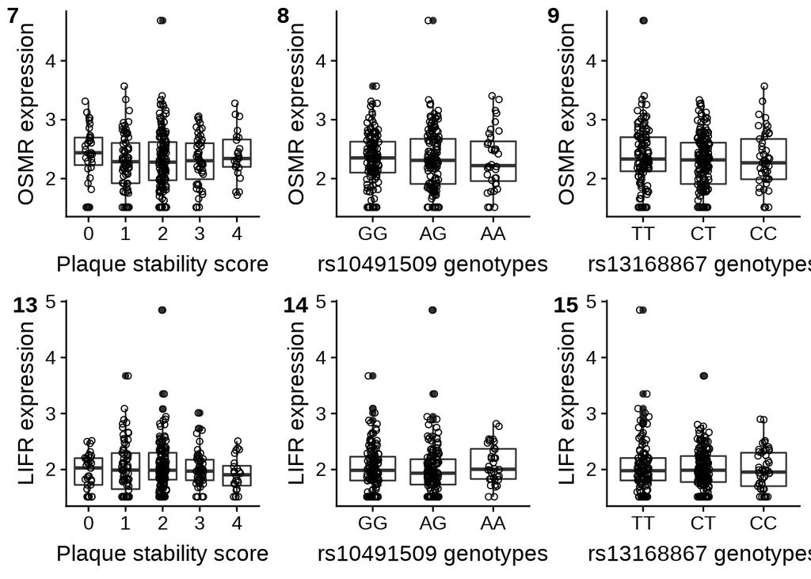

Please note that due to the transformation the y-axis values are different than before, while the overall figure shape and data trend are similar, as you would expect.

# Ordinal logistic regression for stability

Since the outcome variable (stability) is categorized AND ordered, I chose to use ordinal logistic regression in this case.

**OSMR**  
View a summary of the model

```
## Call:
## polr(formula = stability ~ expression_value, data = ggdf_OSMR,
##     Hess = TRUE)
##
## Coefficients:
##                     Value Std. Error t value
## expression_value -0.04985      0.207 -0.2408
##
## Intercepts:
##     Value   Std. Error t value
## 0|1 -2.2435  0.5114    -4.3868
## 1|2 -0.8172  0.4917    -1.6620
## 2|3  1.1050  0.4946     2.2340
## 3|4  2.4272  0.5224     4.6464
##
## Residual Deviance: 931.0264
## AIC: 941.0264
```

Calculate p-values

```
##                        Value Std. Error    t value      p value
## expression_value -0.04984962  0.2070381 -0.2407751 8.097294e-01
## 0|1              -2.24346380  0.5114135 -4.3867901 1.150357e-05
## 1|2              -0.81715909  0.4916599 -1.6620414 9.650448e-02
## 2|3               1.10496565  0.4946200  2.2339686 2.548514e-02
## 3|4               2.42717890  0.5223825  4.6463633 3.378379e-06
```

Assess confidence intervals (CI’s) for the parameter estimates.

Method 1: profiling the likelihood function

```
##      2.5 %     97.5 %
## -0.4568249  0.3561739
```

Method 2: assuming normality

```
##                       2.5 %    97.5 %
## expression_value -0.4556368 0.3559376
```

**Interpreting statistics**  
When assessing above statistical approach, we can conclude the following: there are possible differences between OSMR expression values between consecutive stability scores, based on p-values (three below 0.05), but none based on CI’s (CI crosses zero).  
The THREE p-values that are significant are the comparison between score 0 and 1, between score 2 and 3, and between score 3 and 4. Looking at the graph, these indeed seem the likeliest to differ, although the differences seem to be minimal.

Note however, that for ordinal logistic regression the assumption is that the relationship between each pair of outcome groups is the same. This is called the proportional odds assumption. When assessing this, I’m not so sure whether the data fits this assumption.

An alternative approach is using multinomial logistic regression for stability, assuming that the categoris of the outcome variable (plaque stability) are not ordered.

# Multinomial logistic regression for stability

**OSMR**  
View a summary of the model

```
## Call:
## multinom(formula = stability ~ expression_value, data = ggdf_OSMR)
##
## Coefficients:
##   (Intercept) expression_value
## 1  2.27239941       -0.6472268
## 2  2.65552201       -0.5210405
## 3  1.75919154       -0.5855999
## 4 -0.06341728       -0.1299775
##
## Std. Errors:
##   (Intercept) expression_value
## 1   1.0319529        0.4251272
## 2   0.9462522        0.3856242
## 3   1.1017330        0.4551380
## 4   1.3204688        0.5363657
##
## Residual Deviance: 927.8543
## AIC: 943.8543
```

Calculate p-values using Wald (z) tests

```
##   (Intercept) expression_value
## 1  2.20203795        -1.522431
## 2  2.80635758        -1.351161
## 3  1.59674942        -1.286642
## 4 -0.04802634        -0.242330
```

Because the Wald statistic is asymptotically distributed as a standard normal distribution, we can use the z-score to calculate the p-value.

```
##   (Intercept) expression_value
## 1 0.027662628        0.1279011
## 2 0.005010506        0.1766437
## 3 0.110321575        0.1982190
## 4 0.961695254        0.8085245
```

**Interpreting statistics**  
When looking at the above statistics, in the end the p-values are in the last column. These are p-values for the comparison of OSMR expression values of one of the row denominators (1, 2, 3 or 4, i.e. scores 1-4) and expression values of our baseline stability score 0.

Although non are significant (<0.05), they follow the general trend that we saw in the boxplot for OSMR expression vs. stability scores (see figure 1, left panel).

# Differential expression ## THIS MAY NEED AN UPDATE BASED ON YOUR REPLY

Since this gene analyis is now focused on OSMR and stability, we can be short about differential expression (DE) of the entire dataset, where we analyze DE of all genes between either stability score 0 and 1, 0 and 2, 0 and 3, 1 and 2, 1 and 3, or 2 and 3.

None of these comparisons yielded any DE genes, including OSMR and LIFR. We did find a few DE genes when comparing DE between genotypes of rs13168867, but also here OSMR and LIFR were not included.

In order to not make this document any longer, DE analyses are in a separate R script.